# Introduction to SRTsim

Jiaqiang Zhu

University of Michigan, Department of Biostatistics

Jiaqiang@umich.edu

20 August 2024

#### Package

SRTsim 0.99.7

# 1 Welcome

Welcome to the `SRTsim` project! It is composed of:

- a [shiny](https://shiny.posit.co/) web application that we are hosting at https://jiaqiangzhu.shinyapps.io/srtsim that can handle a limited set of concurrent users,
- a R package at CRAN that lets you generate the spatially resolved transcriptomic (SRT) data and run a local version of our web application.

The web application allows you to design spatial pattern and generate SRT data with patterns of interest.

# 2 Install `SRTsim`

`R` is an open-source statistical environment which can be easily modified to enhance its functionality via packages. *SRTsim* is a `R` package available via CRAN. `R` can be installed on any operating system from [CRAN](https://cran.r-project.org/) after which you can install *SRTsim* by using the following commands in your `R` session:

```r
 install.packages("SRTsim")
```

# 3 Run Reference-Based Simulation

To get started, please load the *SRTsim* package.

```r
library("SRTsim")
```

Once you have installed the package, we can perform reference-based Tissue-wise simulation with the example data.

```r
## explore example SRT data
str(exampleLIBD)
```

```
#> List of 2
#>  $ count:Formal class 'dgCMatrix' [package "Matrix"] with 6 slots
#>   .. ..@ i       : int [1:241030] 1 2 8 9 10 11 13 14 15 16 ...
#>   .. ..@ p       : int [1:3612] 0 67 122 182 252 322 392 462 534 609 ...
#>   .. ..@ Dim     : int [1:2] 80 3611
#>   .. ..@ Dimnames:List of 2
#>   .. .. ..$ : chr [1:80] "ENSG00000175130" "ENSG00000159176" "ENSG00000168314" "ENSG00000080822" ...
#>   .. .. ..$ : chr [1:3611] "AAACAAGTATCTCCCA-1" "AAACAATCTACTAGCA-1" "AAACACCAATAACTGC-1" "AAACAGAGCGACTCCT-1" ...
#>   .. ..@ x       : num [1:241030] 1 1 1 7 10 1 5 2 1 1 ...
#>   .. ..@ factors : list()
#>  $ info :'data.frame':   3611 obs. of  6 variables:
#>   ..$ row     : int [1:3611] 50 3 59 14 43 47 73 61 45 42 ...
#>   ..$ col     : int [1:3611] 102 43 19 94 9 13 43 97 115 28 ...
#>   ..$ imagerow: num [1:3611] 381 126 428 187 341 ...
#>   ..$ imagecol: num [1:3611] 441 260 183 417 153 ...
#>   ..$ tissue  : Factor w/ 2 levels "0","1": 2 2 2 2 2 2 2 2 2 2 ...
#>   ..$ layer   : chr [1:3611] "Layer3" "Layer1" "WM" "Layer3" ...
```

```r
example_count   <- exampleLIBD$count
example_loc     <- exampleLIBD$info[,c("imagecol","imagerow","layer")]
colnames(example_loc) <- c("x","y","label")

## create a SRT object
simSRT  <- createSRT(count_in=example_count,loc_in =example_loc)


## Set a seed for reproducible simulation
set.seed(1)

## Estimate model parameters for data generation
simSRT1 <- srtsim_fit(simSRT,sim_schem="tissue")

## Generate synthetic data with estimated parameters
simSRT1 <- srtsim_count(simSRT1)

## Explore the synthetic data
simCounts(simSRT1)[1:5,1:5]
```

```
#> 5 x 5 sparse Matrix of class "dgCMatrix"
#>                 AAACAAGTATCTCCCA-1 AAACAATCTACTAGCA-1 AAACACCAATAACTGC-1
#> ENSG00000175130                  .                  .                 10
#> ENSG00000159176                  1                  3                  5
#> ENSG00000168314                  1                  .                  6
#> ENSG00000080822                  .                  .                  3
#> ENSG00000091513                  .                  .                  5
#>                 AAACAGAGCGACTCCT-1 AAACAGCTTTCAGAAG-1
#> ENSG00000175130                  .                  2
#> ENSG00000159176                  .                  1
#> ENSG00000168314                  2                  1
#> ENSG00000080822                  1                  .
#> ENSG00000091513                  1                  3
```

```r
simcolData(simSRT1)
```

```
#> DataFrame with 3611 rows and 3 columns
#>                            x         y       label
#>                    <numeric> <numeric> <character>
#> AAACAAGTATCTCCCA-1   440.639   381.098      Layer3
#> AAACAATCTACTAGCA-1   259.631   126.328      Layer1
#> AAACACCAATAACTGC-1   183.078   427.768          WM
#> AAACAGAGCGACTCCT-1   417.237   186.814      Layer3
#> AAACAGCTTTCAGAAG-1   152.700   341.269      Layer5
#> ...                      ...       ...         ...
#> TTGTTTCACATCCAGG-1   254.410   422.862          WM
#> TTGTTTCATTAGTCTA-1   217.147   433.393          WM
#> TTGTTTCCATACAACT-1   208.416   352.430      Layer6
#> TTGTTTGTATTACACG-1   250.720   503.735          WM
#> TTGTTTGTGTAAATTC-1   284.293   148.110      Layer2
```

We can perform reference-based Domain-specific simulation with the example data.

```r
## Set a seed for reproducible simulation
set.seed(1)

## Estimate model parameters for data generation
simSRT2 <- srtsim_fit(simSRT,sim_scheme='domain')

## Generate synthetic data with estimated parameters
simSRT2 <- srtsim_count(simSRT2)

## Explore the synthetic data
simCounts(simSRT2)[1:5,1:5]
```

```
#> 5 x 5 sparse Matrix of class "dgCMatrix"
#>                 AAACAAGTATCTCCCA-1 AAACAATCTACTAGCA-1 AAACACCAATAACTGC-1
#> ENSG00000175130                  .                  .                 11
#> ENSG00000159176                  1                  2                  7
#> ENSG00000168314                  1                  .                  7
#> ENSG00000080822                  .                  .                  3
#> ENSG00000091513                  .                  .                  6
#>                 AAACAGAGCGACTCCT-1 AAACAGCTTTCAGAAG-1
#> ENSG00000175130                  .                  2
#> ENSG00000159176                  .                  1
#> ENSG00000168314                  2                  1
#> ENSG00000080822                  1                  .
#> ENSG00000091513                  2                  3
```

# 4 Comparison Between Reference Data and Synthetic Data

## 4.1 Summarized Metrics

After data generation, we can compare metrics of reference data and synthetic data

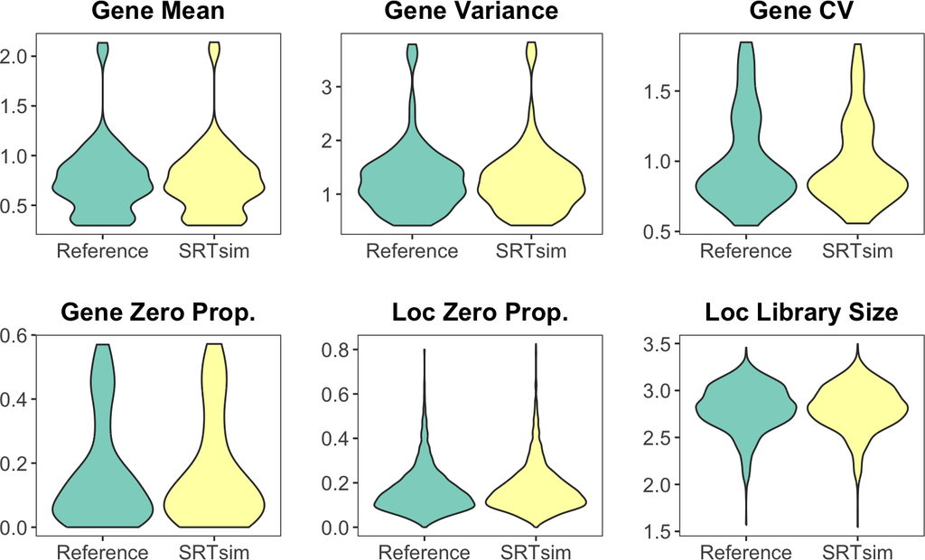

```r
## Compute metrics
simSRT1   <- compareSRT(simSRT1)

## Visualize Metrics
visualize_metrics(simSRT1)
```

## 4.2 Expression Patterns For Genes of Interest

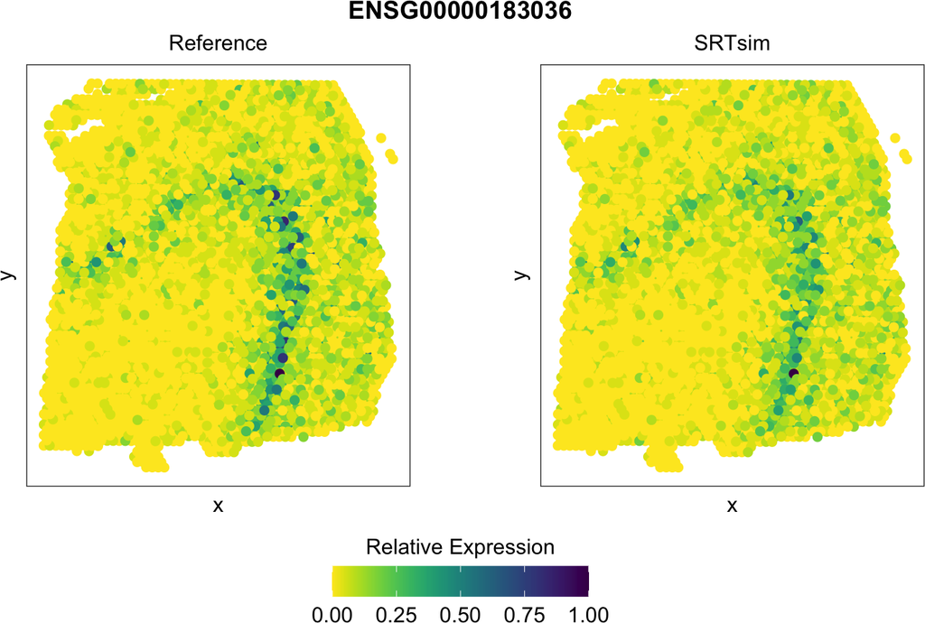

```r
visualize_gene(simsrt=simSRT1,plotgn = "ENSG00000183036",rev_y=TRUE)
```

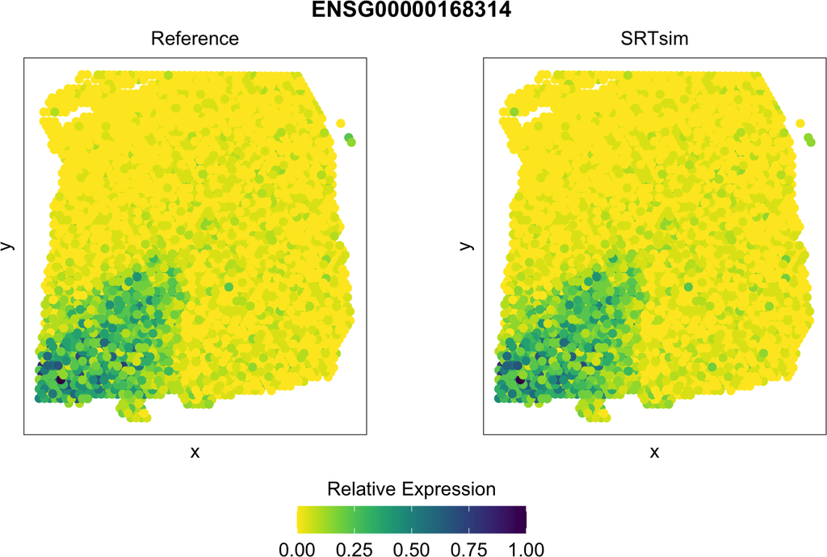

```r
visualize_gene(simsrt=simSRT2,plotgn = "ENSG00000168314",rev_y=TRUE)
```

This work was done by Jiaqiang Zhu, Lulu Shang and Xiang Zhou.

# 5 Reproducibility

The *SRTsim* package was made possible thanks to:

- R (R Core Team, 2024)
- *BiocStyle* (Oleś, 2024)
- *knitr* (Xie, 2014)
- *Matrix* (Bates, Maechler, and Jagan, 2024)
- *RefManageR* (McLean, 2017)
- *rmarkdown* (Allaire, Xie, Dervieux, McPherson, Luraschi, Ushey, Atkins, Wickham, Cheng, Chang, and Iannone, 2024)
- *S4Vectors* (Pagès, Lawrence, and Aboyoun, 2024)
- *sessioninfo* (Wickham, Chang, Flight, Müller, and Hester, 2021)

Code for creating the vignette

```r
## Create the vignette
library("rmarkdown")
system.time(render("SRTsim.Rmd"))

## Extract the R code
library("knitr")
knit("SRTsim.Rmd", tangle = TRUE)
```

Date the vignette was generated.

```
#> [1] "2024-08-20 17:01:59 EDT"
```

Wallclock time spent generating the vignette.

```
#> Time difference of 8.603 secs
```

[session information not shown]

# 6 Bibliography

This vignette was generated using *BiocStyle* (Oleś, 2024), *knitr* (Xie, 2014) and *rmarkdown* (Allaire, Xie, Dervieux et al., 2024) running behind the scenes.

Citations made with *RefManageR* (McLean, 2017).

[1] J. Allaire, Y. Xie, C. Dervieux, et al. *rmarkdown: Dynamic Documents for R*. R package version 2.27. 2024. URL: https://github.com/rstudio/rmarkdown.

[2] D. Bates, M. Maechler, and M. Jagan. *Matrix: Sparse and Dense Matrix Classes and Methods*. R package version 1.7-0. 2024. URL: https://CRAN.R-project.org/package=Matrix.

[3] M. W. McLean. “RefManageR: Import and Manage BibTeX and BibLaTeX References in R”. In: *The Journal of Open Source Software* (2017). DOI: 10.21105/joss.00338.

[4] A. Oleś. *BiocStyle: Standard styles for vignettes and other Bioconductor documents*. R package version 2.32.1. 2024. DOI: 10.18129/B9.bioc.BiocStyle. URL: https://bioconductor.org/packages/BiocStyle.

[5] H. Pagès, M. Lawrence, and P. Aboyoun. *S4Vectors: Foundation of vector-like and list-like containers in Bioconductor*. R package version 0.42.1. 2024. DOI: 10.18129/B9.bioc.S4Vectors. URL: https://bioconductor.org/packages/S4Vectors.

[6] R Core Team. *R: A Language and Environment for Statistical Computing*. R Foundation for Statistical Computing. Vienna, Austria, 2024. URL: https://www.R-project.org/.

[7] H. Wickham, W. Chang, R. Flight, et al. *sessioninfo: R Session Information*. R package version 1.2.2. 2021. URL: https://CRAN.R-project.org/package=sessioninfo.

[8] Y. Xie. “knitr: A Comprehensive Tool for Reproducible Research in R”. In: *Implementing Reproducible Computational Research*. Ed. by V. Stodden, F. Leisch and R. D. Peng. Chapman and Hall/CRC, 2014. ISBN: 978-1466561595. URL: https://www.routledge.com/Implementing-Reproducible-Research/Stodden-Leisch-Peng/p/book/9781466561595.